# R and SQL database

Yujie Wang

When a dataset is too large for R to handle as a whole, one can store the data outside in form of database. Connection between R and the database allows users to retrieve chunks of data for current analysis. This tutorial introduces how to use R to interact with database.

### Load packages

```r
library(dplyr)
library(dbplyr)
library(dbplot)
library(DBI)
```

### Convert csv files to a sqlite file

https://github.com/simonw/csvs-to-sqlite

Installation:

```bash
pip install csvs-to-sqlite
```

Basic Usage:

```bash
csvs-to-sqlite myfile.csv mydatabase.sqlite
```

Convert Multiple csv files into sqlite e.g:

```bash
csvs-to-sqlite ~/Downloads/*.csv my-downloads.sqlite
```

### Build connections

##### common method: load whole data into R

```r
t1 <- system.time(ratings <- read.csv("ratings2.csv"))
cat("Time cost:", t1[1])
```

```
## Time cost: 2.549
```

```r
object.size(ratings)
```

```
## 20972608 bytes
```

```r
head(ratings)
```

```
##   userId movieId rating  timestamp
## 1      1       2    3.5 1112486027
## 2      1      29    3.5 1112484676
## 3      1      32    3.5 1112484819
## 4      1      47    3.5 1112484727
## 5      1      50    3.5 1112484580
## 6      1     112    3.5 1094785740
```

##### build connection with database

```r
t2 <-system.time({
  movielens_con <- DBI::dbConnect(RSQLite::SQLite(), "movielens2.sqlite")
  ratings <- tbl(movielens_con, "ratings2")})
cat("Time cost:", t2[1])
```

```
## Time cost: 0.141
```

```r
src_dbi(movielens_con)
```

```
## src:  sqlite 3.29.0 [/Users/yujiewang/Desktop/sql/movielens2.sqlite]
## tbls: movies, ratings2
```

```r
class(movielens_con)
```

```
## [1] "SQLiteConnection"
## attr(,"package")
## [1] "RSQLite"
```

```r
class(ratings)
```

```
## [1] "tbl_SQLiteConnection" "tbl_dbi"              "tbl_sql"
## [4] "tbl_lazy"             "tbl"
```

```r
object.size(ratings)
```

```
## 5040 bytes
```

```r
head(ratings)
```

```
## # Source:   lazy query [?? x 4]
## # Database: sqlite 3.29.0 [/Users/yujiewang/Desktop/sql/movielens2.sqlite]
##   userId movieId rating  timestamp
##    <int>   <int>  <dbl>      <int>
## 1      1       2    3.5 1112486027
## 2      1      29    3.5 1112484676
## 3      1      32    3.5 1112484819
## 4      1      47    3.5 1112484727
## 5      1      50    3.5 1112484580
## 6      1     112    3.5 1094785740
```

### Querying the database with the SQL syntax

- SQL stands for Structured Query Language
- SQL lets you access and manipulate databases

##### SELECT Syntax

The SELECT statement is used to select data from a database.

```bash
SELECT column1, column2, ...
FROM table_name;
```

example:

```r
res <- dbSendQuery(conn = movielens_con, statement = "SELECT userId, rating from ratings2")
rating_sel <- dbFetch(res)
head(rating_sel)
```

```
##   userId rating
## 1      1    3.5
## 2      1    3.5
## 3      1    3.5
## 4      1    3.5
## 5      1    3.5
## 6      1    3.5
```

```r
dbClearResult(res)
```

##### WHERE Syntax

The WHERE clause is used to filter records.

```bash
SELECT column1, column2, ...
FROM table_name
WHERE condition;
```

example:

```r
res <- dbSendQuery(movielens_con,"SELECT userId, rating, movieId from ratings2 where movieId == 307")
rating307 <- dbFetch(res)
head(rating307)
```

```
##   userId rating movieId
## 1     48      3     307
## 2     69      4     307
## 3    104      4     307
## 4    122      5     307
## 5    124      3     307
## 6    142      4     307
```

```r
dbClearResult(res)
```

##### ORDER BY Syntax

The ORDER BY keyword is used to sort the result-set in ascending or descending order.

```bash
SELECT column1, column2, ...
FROM table_name
ORDER BY column1, column2, ... ASC|DESC;
```

example:

```r
res <- dbSendQuery(movielens_con, "SELECT userId, rating from ratings2 order by rating DESC")
orderedrating <- dbFetch(res)
head(orderedrating)
```

```
##   userId rating
## 1      1      5
## 2      1      5
## 3      1      5
## 4      1      5
## 5      2      5
## 6      2      5
```

```r
dbClearResult(res)
```

##### INSERT INTO Syntax

The INSERT INTO statement is used to insert new records in a table.

```bash
INSERT INTO table_name (column1, column2, column3, ...)
VALUES (value1, value2, value3, ...);
```

example:

```r
dbExecute(movielens_con, "INSERT INTO ratings2 VALUES (0,100, 3, 20190901)")
```

```
## [1] 1
```

```r
res <- dbSendQuery(movielens_con, "Select * from ratings2 where userid == 0")
dbFetch(res)
```

```
##   userId movieId rating timestamp
## 1      0     100      3  20190901
```

```r
dbClearResult(res)
```

##### DELETE Syntax

```bash
DELETE FROM table_name WHERE condition;
```

example:

```r
dbExecute(movielens_con, "delete from ratings2 where userId == 0")
```

```
## [1] 1
```

##### GROUP BY Syntax

The GROUP BY statement groups rows that have the same values into summary rows and is often used with aggregate functions (COUNT, MAX, MIN, SUM, AVG) to group the result-set by one or more columns.

```bash
SELECT column_name(s)
FROM table_name
WHERE condition
GROUP BY column_name(s)
ORDER BY column_name(s);
```

example:

```r
res <- dbSendQuery(movielens_con, "Select movieId, avg(rating) as avg_rating from ratings2
                   group by movieId
                   order by avg_rating desc
                   limit 10")
rating_rank <- dbFetch(res)
rating_rank
```

```
##    movieId avg_rating
## 1      134          5
## 2      672          5
## 3      727          5
## 4     1368          5
## 5     1470          5
## 6     1706          5
## 7     1764          5
## 8     1787          5
## 9     1819          5
## 10    1872          5
```

```r
dbClearResult(res)
```

##### Join

A JOIN clause is used to combine rows from two or more tables, based on a related column between them.

INNER JOIN, LEFT JOIN, RIGHT JOIN

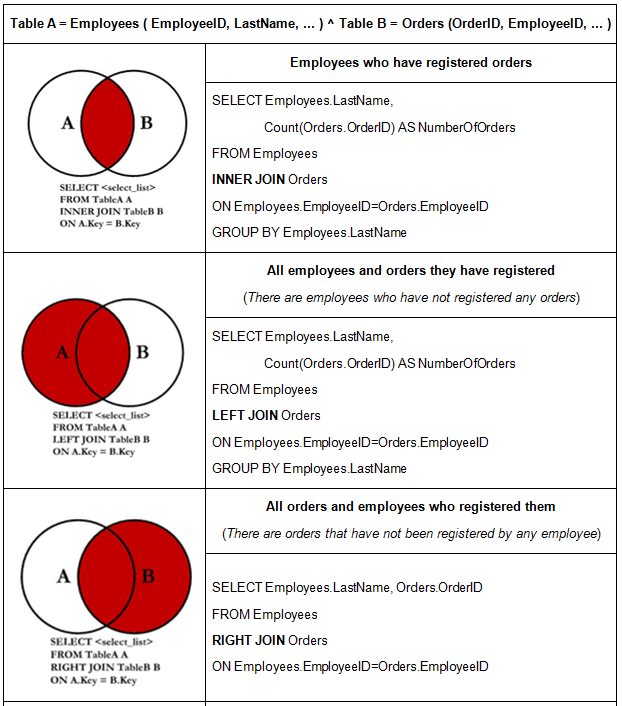

##### Table A

```
##   EID LastName
## 1   1    Lucas
## 2   2    Brown
## 3   3   Jordan
```

##### TableB

```
##   eid OrderID
## 1   1     101
## 2   3     102
## 3   4     103
```

##### Inner Join

```
##   EID LastName OrderID
## 1   1    Lucas     101
## 2   3   Jordan     102
```

##### Left Join

```
##   EID LastName OrderID
## 1   1    Lucas     101
## 2   2    Brown    <NA>
## 3   3   Jordan     102
```

##### Right Join

```
##   EID LastName OrderID
## 1   1    Lucas     101
## 2   3   Jordan     102
## 3   4     <NA>     103
```

example:

```r
movies <- tbl(movielens_con, "movies")
head(movies)
```

```
## # Source:   lazy query [?? x 3]
## # Database: sqlite 3.29.0 [/Users/yujiewang/Desktop/sql/movielens2.sqlite]
##   movieId title                         genres
##     <int> <chr>                         <chr>
## 1       1 Toy Story (1995)              Adventure|Animation|Children|Comed…
## 2       2 Jumanji (1995)                Adventure|Children|Fantasy
## 3       3 Grumpier Old Men (1995)       Comedy|Romance
## 4       4 Waiting to Exhale (1995)      Comedy|Drama|Romance
## 5       5 Father of the Bride Part II … Comedy
## 6       6 Heat (1995)                   Action|Crime|Thriller
```

```r
res <- dbSendQuery(movielens_con,
                    "select ratings2.movieId, title, rating from ratings2
                   inner join movies
                   on ratings2.movieId = movies.movieId
                   limit 10")
join_tbl <- dbFetch(res)
join_tbl
```

```
##    movieId                                                           title
## 1        2                                                  Jumanji (1995)
## 2       29 City of Lost Children, The (Cité des enfants perdus, La) (1995)
## 3       32                       Twelve Monkeys (a.k.a. 12 Monkeys) (1995)
## 4       47                                     Seven (a.k.a. Se7en) (1995)
## 5       50                                      Usual Suspects, The (1995)
## 6      112                      Rumble in the Bronx (Hont faan kui) (1995)
## 7      151                                                  Rob Roy (1995)
## 8      223                                                   Clerks (1994)
## 9      253       Interview with the Vampire: The Vampire Chronicles (1994)
## 10     260                       Star Wars: Episode IV - A New Hope (1977)
##    rating
## 1     3.5
## 2     3.5
## 3     3.5
## 4     3.5
## 5     3.5
## 6     3.5
## 7     4.0
## 8     4.0
## 9     4.0
## 10    4.0
```

```r
dbClearResult(res)
```

### Querying the database with the dplyr syntax

Instead of writing SQL queries, using simpler dplyr’s verbs automatically generate SQL.

##### select()

```r
library(dplyr)
ratings %>% select(userId, rating)
```

```
## # Source:   lazy query [?? x 2]
## # Database: sqlite 3.29.0 [/Users/yujiewang/Desktop/sql/movielens2.sqlite]
##    userId rating
##     <int>  <dbl>
##  1      1    3.5
##  2      1    3.5
##  3      1    3.5
##  4      1    3.5
##  5      1    3.5
##  6      1    3.5
##  7      1    4
##  8      1    4
##  9      1    4
## 10      1    4
## # … with more rows
```

##### filter() = WHERE

```r
ratings %>% filter(movieId == 307)
```

```
## # Source:   lazy query [?? x 4]
## # Database: sqlite 3.29.0 [/Users/yujiewang/Desktop/sql/movielens2.sqlite]
##    userId movieId rating  timestamp
##     <int>   <int>  <dbl>      <int>
##  1     48     307    3    850710783
##  2     69     307    4    867158783
##  3    104     307    4    944918051
##  4    122     307    5    891526949
##  5    124     307    3   1134477521
##  6    142     307    4    833458920
##  7    186     307    3    852546338
##  8    208     307    4    940786460
##  9    237     307    4   1362287433
## 10    241     307    4.5 1343253508
## # … with more rows
```

##### group_by() and summarise()

group_by() takes an existing tbl and converts it into a grouped tbl where operations are performed “by group”

```r
ratings %>% group_by(movieId) %>% summarise(ave_rating = mean(rating))
```

```
## # Source:   lazy query [?? x 2]
## # Database: sqlite 3.29.0 [/Users/yujiewang/Desktop/sql/movielens2.sqlite]
##    movieId ave_rating
##      <int>      <dbl>
##  1       1       3.96
##  2       2       3.27
##  3       3       3.19
##  4       4       3
##  5       5       3.14
##  6       6       3.84
##  7       7       3.38
##  8       8       3.35
##  9       9       3.02
## 10      10       3.43
## # … with more rows
```

##### arrange() = ORDER BY

```r
ratings %>% group_by(movieId) %>% summarise(ave_rating = mean(rating)) %>% arrange(desc(ave_rating))
```

```
## # Source:     lazy query [?? x 2]
## # Database:   sqlite 3.29.0
## #   [/Users/yujiewang/Desktop/sql/movielens2.sqlite]
## # Ordered by: desc(ave_rating)
##    movieId ave_rating
##      <int>      <dbl>
##  1     134          5
##  2     672          5
##  3     727          5
##  4    1368          5
##  5    1470          5
##  6    1706          5
##  7    1764          5
##  8    1787          5
##  9    1819          5
## 10    1872          5
## # … with more rows
```

##### inner_join(), left_join(), right_join()

```r
ratings %>% inner_join(movies, by = c("movieId" = "movieId"), copy=TRUE)
```

```
## # Source:   lazy query [?? x 6]
## # Database: sqlite 3.29.0 [/Users/yujiewang/Desktop/sql/movielens2.sqlite]
##    userId movieId rating  timestamp title                   genres
##     <int>   <int>  <dbl>      <int> <chr>                   <chr>
##  1      1       2    3.5 1112486027 Jumanji (1995)          Adventure|Chil…
##  2      1      29    3.5 1112484676 City of Lost Children,… Adventure|Dram…
##  3      1      32    3.5 1112484819 Twelve Monkeys (a.k.a.… Mystery|Sci-Fi…
##  4      1      47    3.5 1112484727 Seven (a.k.a. Se7en) (… Mystery|Thrill…
##  5      1      50    3.5 1112484580 Usual Suspects, The (1… Crime|Mystery|…
##  6      1     112    3.5 1094785740 Rumble in the Bronx (H… Action|Adventu…
##  7      1     151    4   1094785734 Rob Roy (1995)          Action|Drama|R…
##  8      1     223    4   1112485573 Clerks (1994)           Comedy
##  9      1     253    4   1112484940 Interview with the Vam… Drama|Horror
## 10      1     260    4   1112484826 Star Wars: Episode IV … Action|Adventu…
## # … with more rows
```

### dbplot

Uses very generic dplyr code to aggregate data and then ‘ggplot2’ to create the plot. Because of this approach, the calculations automatically run inside the database if ‘data’ has a database or sparklyr connection.

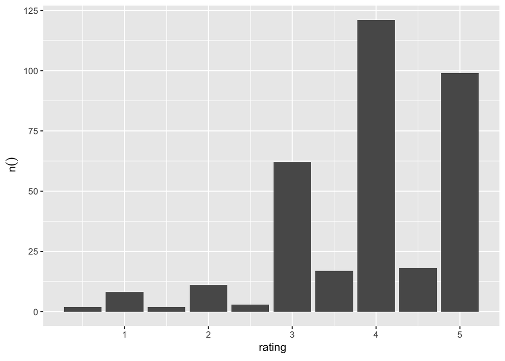

```r
ratings %>% filter(movieId == 307) %>%
dbplot_bar(x = rating)
```

Limitations:

- dbplot only supports a few plot functions (e.g. can not use leaflet to plot data inside databases)
- For other functions do not support database as input: do data processing using sql (dplyr package) instead of directly load the data, then convert the processed data to dataframe.

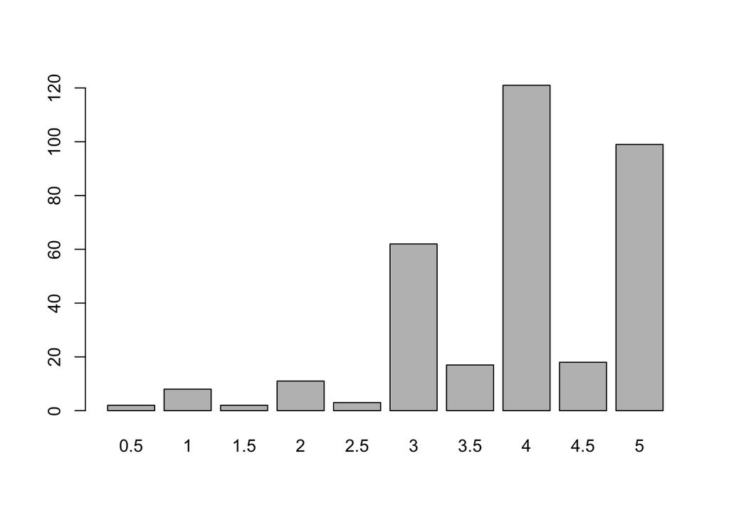

```r
df307 <- data.frame(ratings %>% filter(movieId == 307))
barplot(table(df307$rating))
```

### Disconnection

```r
DBI::dbDisconnect(movielens_con)
```

### References

- https://datacarpentry.org/R-ecology-lesson/05-r-and-databases.html
- https://www.w3schools.com/sql/
- https://www.quora.com/What-is-the-difference-between-various-types-of-joins-For-instance-there%E2%80%99s-inner-join-left-join-right-join-full-join-cross-join-natural-join-equi-join-and-semi-join